# AIC Model Selection

Sarah Zirkle

October 7, 2021

## Tri-colored bat habitat use

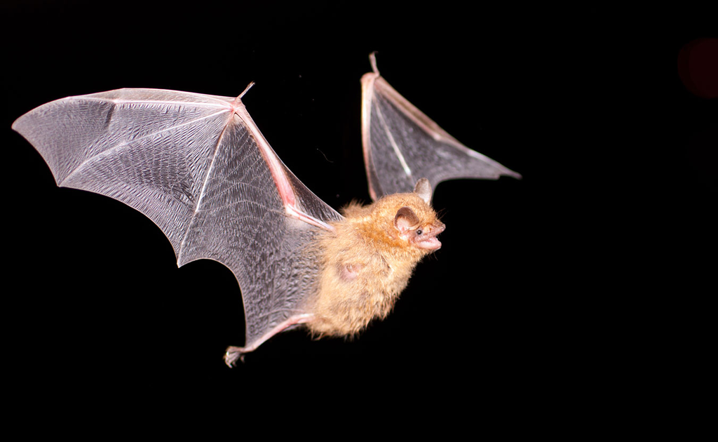

Tri-colored bat

The first data set is once again my own. I am looking at habitat selection at the tree level. This includes includes one response variables: use. My data is in the binomial data as use is 0/1.

All of these variables have been cited as important parts of tree selection for various bat species in the Southeastern U.S.

Lets check for co-linearity among the predictor variables.

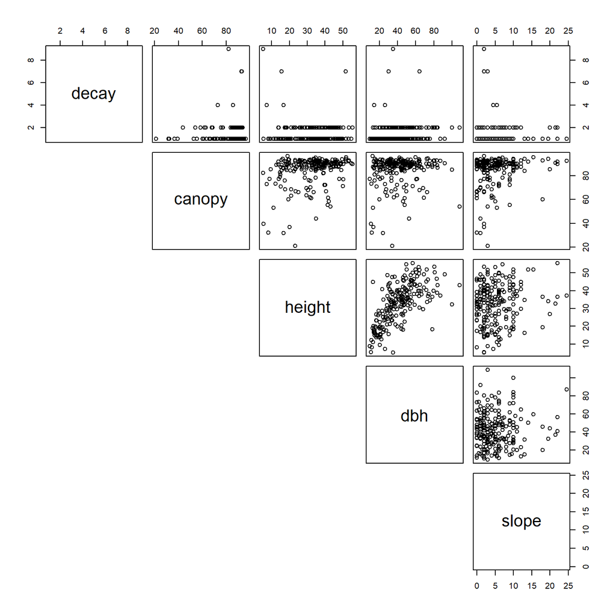

```r
pairs(bats[,2:6], lower.panel = NULL)
```

Seems ok but...... dbh and height look awfully correlated so lets check.

```r
cor(bats$height, bats$dbh)
```

```
## [1] 0.6600357
```

They have a pretty high correlation. Therefore, lets not include both in the same model.

Lets look at the deviance.

```r
model_bat1 <- glm(use ~ dbh + decay + canopy + height + slope, family = binomial(link="logit"), data=bats)
anova (model_bat1)
```

```
## Analysis of Deviance Table
##
## Model: binomial, link: logit
##
## Response: use
##
## Terms added sequentially (first to last)
##
##
##        Df Deviance Resid. Df Resid. Dev
## NULL                     219     247.43
## dbh     1  19.2598       218     228.17
## decay   1   0.4453       217     227.72
## canopy  1   0.7103       216     227.01
## height  1   1.9460       215     225.07
## slope   1   0.5405       214     224.53
```

That DBH though... high deviance.

```r
performance::check_collinearity(model_bat1)
```

```
## # Check for Multicollinearity
##
## Low Correlation
##
##  Parameter  VIF Increased SE
##        dbh 1.51         1.23
##      decay 1.04         1.02
##     canopy 1.08         1.04
##     height 1.53         1.24
##      slope 1.03         1.02
```

Our VIF looks fine for this dataset.

We can now fit some candidate models to explain variation in use.

```r
mod1<-glm(use~height, family = binomial(link="logit"), data = bats)
mod2<-glm(use~height+slope, family = binomial(link="logit"), data = bats)
mod3<-glm(use~height+decay, family = binomial(link="logit"), data = bats)
mod4<-glm(use~height+canopy, family = binomial(link="logit"), data = bats)
```

We will now use model select to conduct model selection.

```r
out.put<-model.sel(mod1,mod2,mod3,mod4)
out.put
```

```
## Model selection table
##      (Intrc)   heght   slope    decay    canpy          family df   logLik  AICc delta
## mod1  -3.147 0.05952                           binomial(logit)  2 -115.866 235.8  0.00
## mod2  -3.228 0.05846 0.02205                   binomial(logit)  3 -115.656 237.4  1.64
## mod4  -3.375 0.05884                  0.002944 binomial(logit)  3 -115.849 237.8  2.02
## mod3  -3.124 0.05958         -0.01771          binomial(logit)  3 -115.863 237.8  2.05
##      weight
## mod1  0.462
## mod2  0.204
## mod4  0.168
## mod3  0.166
## Models ranked by AICc(x)
```

These are the models ranked. Looks like `mod1`, containing an intercept (Int) and height (roost tree height (m)) is best with a weight of 0.462. It is 0.462/0.204 = 2.26 times more likely to be the best explanation (hypothesis) for variation in tree use.

```r
subset(out.put, delta <5)
```

```
## Model selection table
##      (Intrc)   heght   slope    decay    canpy          family df   logLik  AICc delta
## mod1  -3.147 0.05952                           binomial(logit)  2 -115.866 235.8  0.00
## mod2  -3.228 0.05846 0.02205                   binomial(logit)  3 -115.656 237.4  1.64
## mod4  -3.375 0.05884                  0.002944 binomial(logit)  3 -115.849 237.8  2.02
## mod3  -3.124 0.05958         -0.01771          binomial(logit)  3 -115.863 237.8  2.05
##      weight
## mod1  0.462
## mod2  0.204
## mod4  0.168
## mod3  0.166
## Models ranked by AICc(x)
```

```r
subset(out.put, 1/8 < weight/max(out.put$weight))
```

```
## Model selection table
##      (Intrc)   heght   slope    decay    canpy          family df   logLik  AICc delta
## mod1  -3.147 0.05952                           binomial(logit)  2 -115.866 235.8  0.00
## mod2  -3.228 0.05846 0.02205                   binomial(logit)  3 -115.656 237.4  1.64
## mod4  -3.375 0.05884                  0.002944 binomial(logit)  3 -115.849 237.8  2.02
## mod3  -3.124 0.05958         -0.01771          binomial(logit)  3 -115.863 237.8  2.05
##      weight
## mod1  0.462
## mod2  0.204
## mod4  0.168
## mod3  0.166
## Models ranked by AICc(x)
```

```r
subset(out.put, cumsum(out.put$weight) <= .95)
```

```
## Model selection table
##      (Intrc)   heght   slope    canpy          family df   logLik  AICc delta weight
## mod1  -3.147 0.05952                  binomial(logit)  2 -115.866 235.8  0.00  0.554
## mod2  -3.228 0.05846 0.02205          binomial(logit)  3 -115.656 237.4  1.64  0.244
## mod4  -3.375 0.05884         0.002944 binomial(logit)  3 -115.849 237.8  2.02  0.202
## Models ranked by AICc(x)
```

```r
sel.table
```

```
##              K   AICc delta weight
## mod1 -115.8662 235.79  0.00  0.462
## mod2 -115.6561 237.42  1.64  0.204
## mod4 -115.8486 237.81  2.02  0.168
## mod3 -115.8626 237.84  2.05  0.166
```

```r
model.sel(mod1,mod2,mod3,mod4, rank = BIC)
```

```
## Model selection table
##      (Intrc)   heght   slope    decay    canpy          family df   logLik   BIC delta
## mod1  -3.147 0.05952                           binomial(logit)  2 -115.866 242.5  0.00
## mod2  -3.228 0.05846 0.02205                   binomial(logit)  3 -115.656 247.5  4.97
## mod4  -3.375 0.05884                  0.002944 binomial(logit)  3 -115.849 247.9  5.36
## mod3  -3.124 0.05958         -0.01771          binomial(logit)  3 -115.863 247.9  5.39
##      weight
## mod1  0.820
## mod2  0.068
## mod4  0.056
## mod3  0.055
## Models ranked by BIC(x)
```

```r
model.sel(mod1,mod2,mod3,mod4, rank = CAICF)
```

```
## Model selection table
##      (Intrc)   heght   slope    decay    canpy          family df   logLik CAICF delta
## mod1  -3.147 0.05952                           binomial(logit)  2 -115.866 258.4  0.00
## mod3  -3.124 0.05958         -0.01771          binomial(logit)  3 -115.863 268.9 10.51
## mod2  -3.228 0.05846 0.02205                   binomial(logit)  3 -115.656 272.2 13.75
## mod4  -3.375 0.05884                  0.002944 binomial(logit)  3 -115.849 274.1 15.65
##      weight
## mod1  0.993
## mod3  0.005
## mod2  0.001
## mod4  0.000
## Models ranked by CAICF(x)
```

Compare the top models.

```r
AIC(mod1,mod3)
```

```
##      df      AIC
## mod1  2 235.7325
## mod3  3 237.7252
```

Super close.... They are just barely within 2 AIC units.

```r
importance(out.put)
```

```
##                      height slope canopy decay
## Sum of weights:      1.00   0.20  0.17   0.17
## N containing models:    4      1     1      1
```

```r
MA.ests<-model.avg(out.put, revised.var = TRUE)
MA.ests
```

```
##
## Call:
## model.avg(object = out.put, revised.var = TRUE)
##
## Component models:
## '1'  '12' '14' '13'
##
## Coefficients:
##        (Intercept)     height       slope       canopy        decay
## full     -3.198391 0.05920119 0.004495803 0.0004952304 -0.002937164
## subset   -3.198391 0.05920119 0.022047052 0.0029439950 -0.017706995
```

## Red panda habitat use

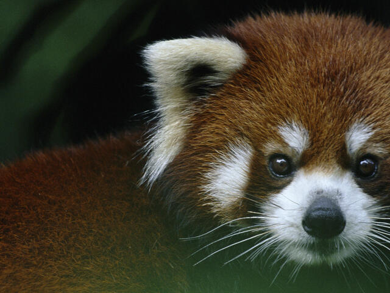

Red panda

For my second example researchers looked at the Red Panda, an endangered habitat specialist, that inhabits a narrow distribution range in bamboo forests along mountain slopes in the Himalaya and Hengduan Mountains.

Their habitat use is different in places with different longitudinal environmental gradients, climatic regimes, and microclimate. In their paper they compared different regions but I chose just to look at their data from Western Nepal.

This subset of data includes the response variable of richness. Five predictor variables are: TreeHigh (tree height), DBH (diameter breast height), Canopy (canopy coverage), BamboAbun (bamboo abundance), and TreeSpeciesRichness (tree species richness).

This study aimed to determine the habitat variables affecting red panda distribution across different longitudinal gradients through a multivariate analysis.

Hopes for the outcome of this study is to highlight the need of importance of bamboo conservation and site pecific conservation planning to ensure long term red panda conservation.

```r
panda <- read.csv("RedPandaSurveyData.csv")
View(panda)
```

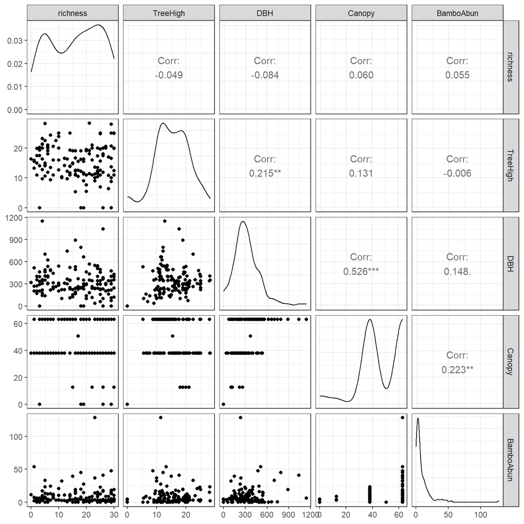

```r
ggpairs(panda, columns = 2:6) + theme_bw()
```

```r
model_panda1 <- lm(richness ~ TreeHigh + DBH + Canopy + BamboAbun + TreeSpeciesRichness, data=panda)
anova (model_panda1)
```

```
## Analysis of Variance Table
##
## Response: richness
##                      Df  Sum Sq Mean Sq F value Pr(>F)
## TreeHigh              1    28.1  28.117  0.3320 0.5654
## DBH                   1    67.4  67.391  0.7957 0.3739
## Canopy                1   179.7 179.672  2.1214 0.1475
## BamboAbun             1    25.6  25.603  0.3023 0.5833
## TreeSpeciesRichness   1     9.1   9.134  0.1078 0.7431
## Residuals           137 11603.1  84.694
```

We can check for multicollinearity.

```r
performance::check_collinearity(model_panda1)
```

```
## # Check for Multicollinearity
##
## Low Correlation
##
##            Parameter  VIF Increased SE
##             TreeHigh 1.12         1.06
##                  DBH 1.43         1.20
##               Canopy 1.48         1.22
##            BamboAbun 1.06         1.03
##  TreeSpeciesRichness 1.17         1.08
```

Our VIF is less than 5 indicating a low correlation of that predictor with other predictors.

Now, lets set up our models.

```r
m1<-lm(richness ~ Canopy + DBH +BamboAbun + TreeSpeciesRichness, data = panda)
m2<-lm(richness~Canopy + TreeHigh +DBH + BamboAbun + TreeSpeciesRichness, data = panda)
m3<-lm(richness~DBH + BamboAbun + TreeSpeciesRichness, data = panda)
m4<-lm(richness~TreeHigh + TreeSpeciesRichness + Canopy, data = panda)
```

```r
out.put1<-model.sel(m1,m2,m3,m4)
out.put1
```

```
## Model selection table
##    (Intrc)   BmbAb   Canpy       DBH   TrSpR    TrHgh             family df   logLik
## m3   17.22 0.04505         -0.004469 -0.1028          gaussian(identity)  5 -518.269
## m1   15.12 0.03289 0.07721 -0.007721 -0.2956          gaussian(identity)  6 -517.278
## m4   15.77         0.04127           -0.2737 -0.07637 gaussian(identity)  5 -518.563
## m2   15.57 0.03195 0.07690 -0.007497 -0.2443 -0.03956 gaussian(identity)  7 -517.235
##      AICc delta weight
## m3 1047.0  0.00  0.337
## m1 1047.2  0.20  0.306
## m4 1047.6  0.59  0.252
## m2 1049.3  2.32  0.106
## Models ranked by AICc(x)
```

```r
subset(out.put1, delta <5)
```

```
## Model selection table
##    (Intrc)   BmbAb   Canpy       DBH   TrSpR    TrHgh             family df   logLik
## m3   17.22 0.04505         -0.004469 -0.1028          gaussian(identity)  5 -518.269
## m1   15.12 0.03289 0.07721 -0.007721 -0.2956          gaussian(identity)  6 -517.278
## m4   15.77         0.04127           -0.2737 -0.07637 gaussian(identity)  5 -518.563
## m2   15.57 0.03195 0.07690 -0.007497 -0.2443 -0.03956 gaussian(identity)  7 -517.235
##      AICc delta weight
## m3 1047.0  0.00  0.337
## m1 1047.2  0.20  0.306
## m4 1047.6  0.59  0.252
## m2 1049.3  2.32  0.106
## Models ranked by AICc(x)
```

```r
subset(out.put1, 1/8 < weight/max(out.put1$weight))
```

```
## Model selection table
##    (Intrc)   BmbAb   Canpy       DBH   TrSpR    TrHgh             family df   logLik
## m3   17.22 0.04505         -0.004469 -0.1028          gaussian(identity)  5 -518.269
## m1   15.12 0.03289 0.07721 -0.007721 -0.2956          gaussian(identity)  6 -517.278
## m4   15.77         0.04127           -0.2737 -0.07637 gaussian(identity)  5 -518.563
## m2   15.57 0.03195 0.07690 -0.007497 -0.2443 -0.03956 gaussian(identity)  7 -517.235
##      AICc delta weight
## m3 1047.0  0.00  0.337
## m1 1047.2  0.20  0.306
## m4 1047.6  0.59  0.252
## m2 1049.3  2.32  0.106
## Models ranked by AICc(x)
```

```r
names(sel.table1)[1] = "K"
sel.table1
```

```
##    K  logLik    AICc delta weight
## m3 5 -518.27 1046.98 0.000  0.337
## m1 6 -517.28 1047.17 0.198  0.306
## m4 5 -518.56 1047.56 0.587  0.252
## m2 7 -517.24 1049.30 2.324  0.106
```

This model ranking still has `m3` with the top weight.

```r
# model selection table; sorted by BIC
model.sel(m1,m2,m3,m4, rank = BIC)
```

```
## Model selection table
##    (Intrc)   BmbAb   Canpy       DBH   TrSpR    TrHgh             family df   logLik
## m3   17.22 0.04505         -0.004469 -0.1028          gaussian(identity)  5 -518.269
## m4   15.77         0.04127           -0.2737 -0.07637 gaussian(identity)  5 -518.563
## m1   15.12 0.03289 0.07721 -0.007721 -0.2956          gaussian(identity)  6 -517.278
## m2   15.57 0.03195 0.07690 -0.007497 -0.2443 -0.03956 gaussian(identity)  7 -517.235
##       BIC delta weight
## m3 1061.4  0.00  0.502
## m4 1061.9  0.59  0.375
## m1 1064.3  2.98  0.113
## m2 1069.2  7.86  0.010
## Models ranked by BIC(x)
```

```r
#consistent AIC with Fishers information matrix
model.sel(m1,m2,m3,m4, rank = CAICF)
```

```
## Model selection table
##    (Intrc)   BmbAb   Canpy       DBH   TrSpR    TrHgh             family df   logLik
## m4   15.77         0.04127           -0.2737 -0.07637 gaussian(identity)  5 -518.563
## m3   17.22 0.04505         -0.004469 -0.1028          gaussian(identity)  5 -518.269
## m1   15.12 0.03289 0.07721 -0.007721 -0.2956          gaussian(identity)  6 -517.278
## m2   15.57 0.03195 0.07690 -0.007497 -0.2443 -0.03956 gaussian(identity)  7 -517.235
##     CAICF delta weight
## m4 1083.3  0.00  0.954
## m3 1089.4  6.09  0.045
## m1 1100.1 16.87  0.000
## m2 1110.9 27.68  0.000
## Models ranked by CAICF(x)
```

```r
AIC(m1,m3,m4)
```

```
##    df      AIC
## m1  6 1046.556
## m3  5 1046.538
## m4  5 1047.125
```

```r
importance(out.put1)
```

```
##                      TreeSpeciesRichness BamboAbun DBH  Canopy TreeHigh
## Sum of weights:      1.00                0.75      0.75 0.66   0.36
## N containing models:    4                   3         3    3      2
```

```r
MA.ests1<-model.avg(out.put1, revised.var = TRUE)
MA.ests1
```

```
##
## Call:
## model.avg(object = out.put1, revised.var = TRUE)
##
## Component models:
## '134'   '1234'  '245'   '12345'
##
## Coefficients:
##        (Intercept)          DBH  BamboAbun TreeSpeciesRichness     Canopy    TreeHigh
## full       16.0401 -0.004658178 0.02861999           -0.219633 0.04209314 -0.02338468
## subset     16.0401 -0.006223601 0.03823799           -0.219633 0.06351976 -0.06548906
```

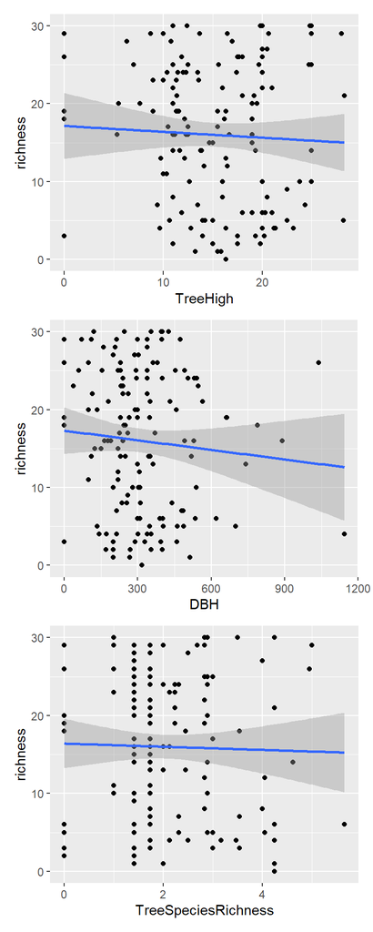

```r
w1 <- ggplot(panda, aes(TreeHigh, richness)) +
  geom_point() +
  geom_smooth(method="lm")

w2 <- ggplot(panda, aes(DBH, richness)) +
  geom_point() +
  geom_smooth(method="lm")

w3 <- ggplot(panda, aes(TreeSpeciesRichness, richness)) +
  geom_point() +
  geom_smooth(method="lm")

w1 / w2 / w3
```